# VisualEDA_Fetch_Analysis

## Visualizations:

### Exploratory data analysis (EDA) using visualizations to uncover trends or anomalies

### Key Questions for Visualizations:

#### 1. User Insights

#### 2. Product Categories

#### 3. Sales Trends

## Data Exploration

We start by loading the cleaned datasets and checking their basic structure. This helps us understand the number of rows, columns, and the type of data available in each dataset before we proceed with further analysis.

- **Users Dataset**: Contains user demographic information.
- **Products Dataset**: Includes information about the products sold.
- **Transactions Dataset**: Holds transaction data, including purchase amounts and product IDs.

Next, we will check the basic info of each dataset to get a better understanding of the data before performing any analysis.

```python
# Before starting the Visualizations, we need to import MatplotLib and Seaborn Libraries.
```

```python
# Importing the necessary libraries for Visualization
# Setup and configuration

import pandas as pd
import numpy as np
import matplotlib.pyplot as plt
import seaborn as sns

# Step 1: Loading the cleaned datasets
users = pd.read_csv("cleaned_USER_TAKEHOME.csv")
products = pd.read_csv("cleaned_PRODUCT_TAKEHOME.csv")
transactions = pd.read_csv("cleaned_TRANSACTION_TAKEHOME.csv")

# Step2: Display basic info for each dataset
print("\nUsers Dataset Info:")
users.info()
print("\nProducts Dataset Info:")
products.info()
print("Transactions Dataset Info:")
transactions.info()
```

```
Users Dataset Info:
<class 'pandas.core.frame.DataFrame'>
RangeIndex: 100000 entries, 0 to 99999
Data columns (total 7 columns):
 #   Column        Non-Null Count   Dtype
---  ------        --------------   -----
 0   ID            100000 non-null  object
 1   CREATED_DATE  100000 non-null  object
 2   BIRTH_DATE    96325 non-null   object
 3   STATE         100000 non-null  object
 4   LANGUAGE      100000 non-null  object
 5   GENDER        100000 non-null  object
 6   AGE           100000 non-null  float64
dtypes: float64(1), object(6)
memory usage: 5.3+ MB

Products Dataset Info:
<class 'pandas.core.frame.DataFrame'>
RangeIndex: 841342 entries, 0 to 841341
Data columns (total 7 columns):
 #   Column        Non-Null Count   Dtype
---  ------        --------------   -----
 0   CATEGORY_1    841342 non-null  object
 1   CATEGORY_2    841342 non-null  object
 2   CATEGORY_3    841342 non-null  object
 3   CATEGORY_4    841342 non-null  object
 4   MANUFACTURER  836507 non-null  object
 5   BRAND         841342 non-null  object
 6   BARCODE       841342 non-null  float64
dtypes: float64(1), object(6)
memory usage: 44.9+ MB
Transactions Dataset Info:
<class 'pandas.core.frame.DataFrame'>
RangeIndex: 49829 entries, 0 to 49828
Data columns (total 10 columns):
 #   Column           Non-Null Count  Dtype
---  ------           --------------  -----
 0   RECEIPT_ID       49829 non-null  object
 1   PURCHASE_DATE    49829 non-null  object
 2   SCAN_DATE        49829 non-null  object
 3   STORE_NAME       49829 non-null  object
 4   USER_ID          49829 non-null  object
 5   BARCODE          44094 non-null  float64
 6   FINAL_QUANTITY   49829 non-null  float64
 7   FINAL_SALE       49829 non-null  float64
 8   BARCODE_MISSING  49829 non-null  bool
 9   IS_MULTI_ITEM    49829 non-null  bool
dtypes: bool(2), float64(3), object(5)
memory usage: 3.1+ MB
```

```python
# Check the shape of each dataset
print("Users Dataset Shape:", users.shape)
print("Products Dataset Shape:", products.shape)
print("Transactions Dataset Shape:", transactions.shape)
```

```
Users Dataset Shape: (100000, 7)
Products Dataset Shape: (841342, 7)
Transactions Dataset Shape: (49829, 10)
```

```python
# Display the first few rows of each dataset
print("Users Dataset Preview:")
print(users.head())
```

```
Users Dataset Preview:
                         ID               CREATED_DATE  \
0  5ef3b4f17053ab141787697d  2020-06-24 20:17:54+00:00
1  5ff220d383fcfc12622b96bc  2021-01-03 19:53:55+00:00
2  6477950aa55bb77a0e27ee10  2023-05-31 18:42:18+00:00
3  658a306e99b40f103b63ccf8  2023-12-26 01:46:22+00:00
4  653cf5d6a225ea102b7ecdc2  2023-10-28 11:51:50+00:00

                  BIRTH_DATE STATE LANGUAGE   GENDER   AGE
0  2000-08-11 00:00:00+00:00    CA  SPANISH   FEMALE  25.0
1  2001-09-24 04:00:00+00:00    PA  ENGLISH   FEMALE  24.0
2  1994-10-28 00:00:00+00:00    FL  SPANISH   FEMALE  31.0
3                        NaN    NC  ENGLISH  unknown  -1.0
4  1972-03-19 00:00:00+00:00    PA  ENGLISH   FEMALE  53.0
```

```python
print("\nProducts Dataset Preview:")
print(products.head())
```

```
Products Dataset Preview:
          CATEGORY_1              CATEGORY_2                   CATEGORY_3  \
0  Health & Wellness           Sexual Health  Conductivity Gels & Lotions
1             Snacks           Puffed Snacks         Cheese Curls & Puffs
2  Health & Wellness               Hair Care        Hair Care Accessories
3  Health & Wellness               Oral Care                   Toothpaste
4  Health & Wellness  Medicines & Treatments               Essential Oils

  CATEGORY_4                                       MANUFACTURER  \
0    Unknown                                            Unknown
1    Unknown                                            Unknown
2    Unknown                           Placeholder Manufacturer
3    Unknown                                  Colgate-Palmolive
4    Unknown  Maple Holistics And Honeydew Products Intercha...

             BRAND       BARCODE
0          Unknown  7.964944e+11
1          Unknown  2.327801e+10
2          Elecsop  4.618178e+11
3          Colgate  3.500047e+10
4  Maple Holistics  8.068109e+11
```

```python
print("\nTransactions Dataset Preview:")
print(transactions.head())
```

```
Transactions Dataset Preview:
                             RECEIPT_ID PURCHASE_DATE  \
0  0000d256-4041-4a3e-adc4-5623fb6e0c99    2024-08-21
1  0001455d-7a92-4a7b-a1d2-c747af1c8fd3    2024-07-20
2  00017e0a-7851-42fb-bfab-0baa96e23586    2024-08-18
3  000239aa-3478-453d-801e-66a82e39c8af    2024-06-18
4  00026b4c-dfe8-49dd-b026-4c2f0fd5c6a1    2024-07-04

                 SCAN_DATE STORE_NAME                   USER_ID       BARCODE  \
0  2024-08-21 14:19:06.539    Walmart  63b73a7f3d310dceeabd4758  1.530001e+10
1  2024-07-20 09:50:24.206       Aldi  62c08877baa38d1a1f6c211a           NaN
2  2024-08-19 15:38:56.813    Walmart  60842f207ac8b7729e472020  7.874223e+10
3  2024-06-19 11:03:37.468  Food Lion  63fcd7cea4f8442c3386b589  7.833997e+11
4  2024-07-05 15:56:43.549   Randalls  6193231ae9b3d75037b0f928  4.790050e+10

   FINAL_QUANTITY  FINAL_SALE  BARCODE_MISSING  IS_MULTI_ITEM
0             1.0    4.335635            False          False
1             1.0    1.490000             True          False
2             1.0    4.335635            False          False
3             1.0    3.490000            False          False
4             1.0    4.335635            False          False
```

```python
# Handling Missing BIRTH_DATE in Users Dataset
# Assumptions:
# - Ensure both BIRTH_DATE and the current timestamp are timezone-naive for consistency.

# Step 1: Replace missing BIRTH_DATE with "1900-01-01"
users['BIRTH_DATE'] = users['BIRTH_DATE'].fillna('1900-01-01')

# Step 2: Convert BIRTH_DATE to datetime, handling invalid formats
users['BIRTH_DATE'] = pd.to_datetime(users['BIRTH_DATE'], errors='coerce')

# Step 3: Explicitly remove timezone awareness from BIRTH_DATE
users['BIRTH_DATE'] = users['BIRTH_DATE'].dt.tz_localize(None)

# Step 4: Use timezone-naive current timestamp for comparison
current_date_naive = pd.Timestamp.now().tz_localize(None)

# Step 5: Recalculate AGE based on the updated BIRTH_DATE
users['AGE'] = (current_date_naive - users['BIRTH_DATE']).dt.days // 365

# Step 6: Verify the changes
print("\nUpdated Users Dataset Missing Values Summary:")
print(users.isnull().sum())
print("\nSample of Users Dataset:")
print(users.head())
```

```
Updated Users Dataset Missing Values Summary:
ID                 0
CREATED_DATE       0
BIRTH_DATE      3675
STATE              0
LANGUAGE           0
GENDER             0
AGE             3675
dtype: int64

Sample of Users Dataset:
                         ID               CREATED_DATE          BIRTH_DATE  \
0  5ef3b4f17053ab141787697d  2020-06-24 20:17:54+00:00 2000-08-11 00:00:00
1  5ff220d383fcfc12622b96bc  2021-01-03 19:53:55+00:00 2001-09-24 04:00:00
2  6477950aa55bb77a0e27ee10  2023-05-31 18:42:18+00:00 1994-10-28 00:00:00
3  658a306e99b40f103b63ccf8  2023-12-26 01:46:22+00:00                 NaT
4  653cf5d6a225ea102b7ecdc2  2023-10-28 11:51:50+00:00 1972-03-19 00:00:00

  STATE LANGUAGE   GENDER   AGE
0    CA  SPANISH   FEMALE  24.0
1    PA  ENGLISH   FEMALE  23.0
2    FL  SPANISH   FEMALE  30.0
3    NC  ENGLISH  unknown   NaN
4    PA  ENGLISH   FEMALE  52.0
```

```python
try:
    users = pd.read_csv("cleaned_USER_TAKEHOME.csv")
    products = pd.read_csv("cleaned_PRODUCT_TAKEHOME.csv")
    transactions = pd.read_csv("cleaned_TRANSACTION_TAKEHOME.csv")
except FileNotFoundError as e:
    print(f"Error loading data: {e}")
    raise
```

```python
print(users.head())
```

```
                         ID               CREATED_DATE  \
0  5ef3b4f17053ab141787697d  2020-06-24 20:17:54+00:00
1  5ff220d383fcfc12622b96bc  2021-01-03 19:53:55+00:00
2  6477950aa55bb77a0e27ee10  2023-05-31 18:42:18+00:00
3  658a306e99b40f103b63ccf8  2023-12-26 01:46:22+00:00
4  653cf5d6a225ea102b7ecdc2  2023-10-28 11:51:50+00:00

                  BIRTH_DATE STATE LANGUAGE   GENDER   AGE
0  2000-08-11 00:00:00+00:00    CA  SPANISH   FEMALE  25.0
1  2001-09-24 04:00:00+00:00    PA  ENGLISH   FEMALE  24.0
2  1994-10-28 00:00:00+00:00    FL  SPANISH   FEMALE  31.0
3                        NaN    NC  ENGLISH  unknown  -1.0
4  1972-03-19 00:00:00+00:00    PA  ENGLISH   FEMALE  53.0
```

```python
# Handling Missing MANUFACTURER in Products Dataset
# Assumptions:
# - Missing manufacturer data might represent unknown manufacturers.
# - Replace missing values with "Unknown" for clarity.

# Step 1: Replace missing MANUFACTURER values with "Unknown"
products['MANUFACTURER'] = products['MANUFACTURER'].fillna('Unknown')

# Step 2: Verify the changes
print("\nUpdated Products Dataset Missing Values Summary:")
print(products.isnull().sum())
print("\nSample of Products Dataset:")
print(products.head())
```

```
Updated Products Dataset Missing Values Summary:
CATEGORY_1      0
CATEGORY_2      0
CATEGORY_3      0
CATEGORY_4      0
MANUFACTURER    0
BRAND           0
BARCODE         0
dtype: int64

Sample of Products Dataset:
          CATEGORY_1              CATEGORY_2                   CATEGORY_3  \
0  Health & Wellness           Sexual Health  Conductivity Gels & Lotions
1             Snacks           Puffed Snacks         Cheese Curls & Puffs
2  Health & Wellness               Hair Care        Hair Care Accessories
3  Health & Wellness               Oral Care                   Toothpaste
4  Health & Wellness  Medicines & Treatments               Essential Oils

  CATEGORY_4                                       MANUFACTURER  \
0    Unknown                                            Unknown
1    Unknown                                            Unknown
2    Unknown                           Placeholder Manufacturer
3    Unknown                                  Colgate-Palmolive
4    Unknown  Maple Holistics And Honeydew Products Intercha...

             BRAND       BARCODE
0          Unknown  7.964944e+11
1          Unknown  2.327801e+10
2          Elecsop  4.618178e+11
3          Colgate  3.500047e+10
4  Maple Holistics  8.068109e+11
```

```python
# Handling Missing BARCODE in Transactions Dataset
# Assumptions:
# - Missing BARCODE may represent incomplete or unrecorded transactions.
# - Replace missing values with "MISSING" to retain these rows for analysis.

# Step 1: Replace missing BARCODE values with "MISSING"
transactions['BARCODE'] = transactions['BARCODE'].fillna('MISSING')

# Step 2: Verify the changes
print("\nUpdated Transactions Dataset Missing Values Summary:")
print(transactions.isnull().sum())
print("\nSample of Transactions Dataset:")
print(transactions.head())
```

```
Updated Transactions Dataset Missing Values Summary:
RECEIPT_ID         0
PURCHASE_DATE      0
SCAN_DATE          0
STORE_NAME         0
USER_ID            0
BARCODE            0
FINAL_QUANTITY     0
FINAL_SALE         0
BARCODE_MISSING    0
IS_MULTI_ITEM      0
dtype: int64

Sample of Transactions Dataset:
                             RECEIPT_ID PURCHASE_DATE  \
0  0000d256-4041-4a3e-adc4-5623fb6e0c99    2024-08-21
1  0001455d-7a92-4a7b-a1d2-c747af1c8fd3    2024-07-20
2  00017e0a-7851-42fb-bfab-0baa96e23586    2024-08-18
3  000239aa-3478-453d-801e-66a82e39c8af    2024-06-18
4  00026b4c-dfe8-49dd-b026-4c2f0fd5c6a1    2024-07-04

                 SCAN_DATE STORE_NAME                   USER_ID  \
0  2024-08-21 14:19:06.539    Walmart  63b73a7f3d310dceeabd4758
1  2024-07-20 09:50:24.206       Aldi  62c08877baa38d1a1f6c211a
2  2024-08-19 15:38:56.813    Walmart  60842f207ac8b7729e472020
3  2024-06-19 11:03:37.468  Food Lion  63fcd7cea4f8442c3386b589
4  2024-07-05 15:56:43.549   Randalls  6193231ae9b3d75037b0f928

          BARCODE  FINAL_QUANTITY  FINAL_SALE  BARCODE_MISSING  IS_MULTI_ITEM
0   15300014978.0             1.0    4.335635            False          False
1         MISSING             1.0    1.490000             True          False
2   78742229751.0             1.0    4.335635            False          False
3  783399746536.0             1.0    3.490000            False          False
4   47900501183.0             1.0    4.335635            False          False
```

## Data Cleaning and Preprocessing

- **Missing Values**: Columns with missing values were identified and handled (e.g., imputation or removal).
- **Duplicates**: Duplicate rows were removed to ensure clean data.
- **Data Type Conversion**: Some columns were converted to the appropriate data types (e.g., `PURCHASE_DATE` to datetime).
- **Assumptions**: Missing or invalid values were handled based on assumptions, such as treating unknown categories as 'unknown'.

**Basic EDA For User Dataset**

```python
# Analyzing AGE Distribution and key demographics like STATE and GENDER
```

```python
# Users Dataset: Summary Statistics
# Step 1: Display summary statistics for numerical columns
print("\nUsers Dataset Summary Statistics:")
print(users.describe())
```

```
Users Dataset Summary Statistics:
                AGE
count  100000.00000
mean       39.29070
std        16.83208
min        -1.00000
25%        26.00000
50%        39.00000
75%        51.00000
max       125.00000
```

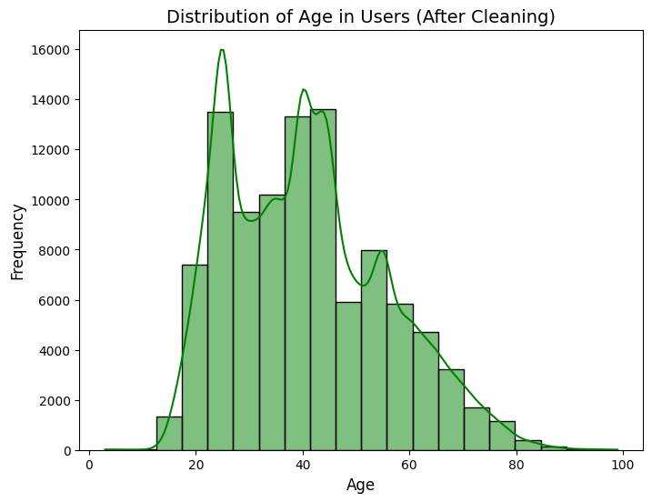

```python
# Handling Age Outliers in Users Dataset
# Assumptions:
# - Age below 0 and above 100 is considered unrealistic.
# - Replace such values with the median age of the dataset.
# Step 1: Identify median age (ignoring negative values)
median_age = users.loc[(users['AGE'] >= 0) & (users['AGE'] <= 100), 'AGE'].median()

# Step 2: Replace outliers (AGE < 0 or AGE > 100) with the median age
users.loc[(users['AGE'] < 0) | (users['AGE'] > 100), 'AGE'] = median_age

# Step 3: Verify changes with a histogram
plt.figure(figsize=(8, 6))
sns.histplot(users['AGE'], bins=20, kde=True, color='green')
plt.title("Distribution of Age in Users (After Cleaning)", fontsize=14)
plt.xlabel("Age", fontsize=12)
plt.ylabel("Frequency", fontsize=12)
plt.show()
```

**What the Graph Shows:**

- The plot displays the number of users grouped by age ranges.

**Key Points:**

**Insights for Business:**

1. Focus on the 20–60 age group, as they form the majority of the users.
2. Consider strategies to engage younger (<20) and older (>60) audiences to grow the user base.

```python
print(users.head())  # Display the first few rows of users dataset
print(transactions.head())  # Display the first few rows of transactions dataset
```

```
                         ID               CREATED_DATE  \
0  5ef3b4f17053ab141787697d  2020-06-24 20:17:54+00:00
1  5ff220d383fcfc12622b96bc  2021-01-03 19:53:55+00:00
2  6477950aa55bb77a0e27ee10  2023-05-31 18:42:18+00:00
3  658a306e99b40f103b63ccf8  2023-12-26 01:46:22+00:00
4  653cf5d6a225ea102b7ecdc2  2023-10-28 11:51:50+00:00

                  BIRTH_DATE STATE LANGUAGE   GENDER   AGE
0  2000-08-11 00:00:00+00:00    CA  SPANISH   FEMALE  25.0
1  2001-09-24 04:00:00+00:00    PA  ENGLISH   FEMALE  24.0
2  1994-10-28 00:00:00+00:00    FL  SPANISH   FEMALE  31.0
3                        NaN    NC  ENGLISH  unknown  40.0
4  1972-03-19 00:00:00+00:00    PA  ENGLISH   FEMALE  53.0
                             RECEIPT_ID PURCHASE_DATE  \
0  0000d256-4041-4a3e-adc4-5623fb6e0c99    2024-08-21
```

[output cut: 18 more lines]